# Analisis Estadistico TAE

Andrés Camilo García Moreno

11/03/2022

Analisis descriptivo de estudiantes en el curso de Tecnicas de Aprendizaje Estadistico (TAE) 2022-1

Primero analizaremos que programas academicos los estudiantes escogen más, como podemos ver en la grafica ,los estudiantes del programa academico de Ingenieria de Sistemas e Informática conforman mas del 50% de los estudiantes inscritos en el curso de TAE, seguido de Estadística que conforma poco mas del 20%, mientras que los estudiantes de Ingenieria Civil ,Ingeniería Biológica, Ingeniería Eléctrica,Mathematical Data Science e Ingeniería Industrial conforman el grupo mas pequeño con 1 estudiante por programa academico , sin embargo hay 2 estudiantes que no especifican a que programa académico pertenecen.

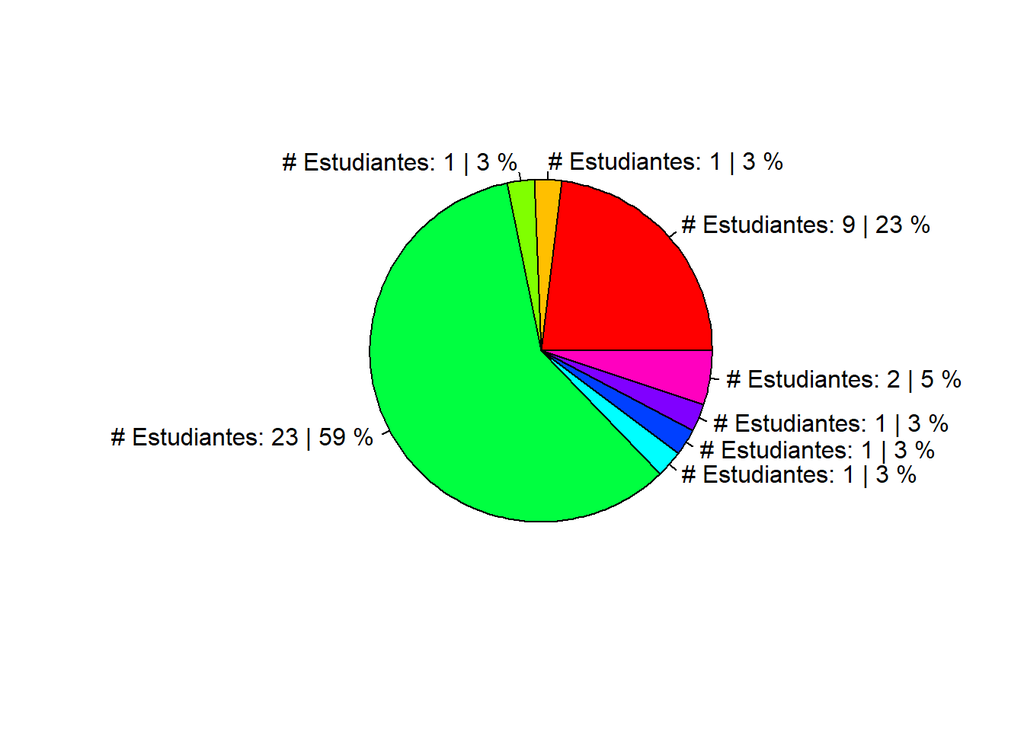

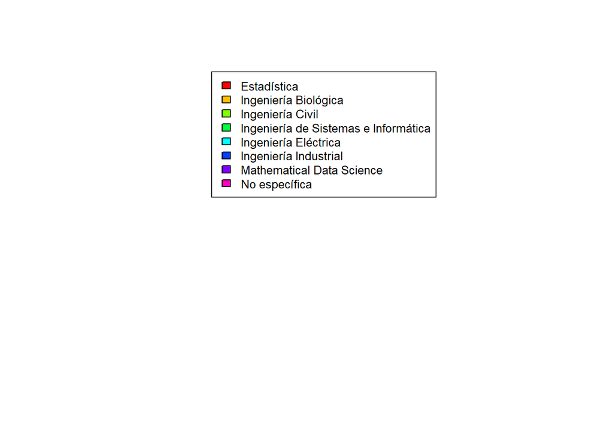

En cuanto el tipo de hobby que prefieren los estudiantes , estos prefieren los videojuegos , seguido muy de cerca de deporte y/o actividades fisicas En cuanto al resto actividades relacionadas con la musica tiene una cantidad decente, mientras que el resto de pasatiempos solo cuentan con 1 o 2 estudiantes que los consideran como su preferido.

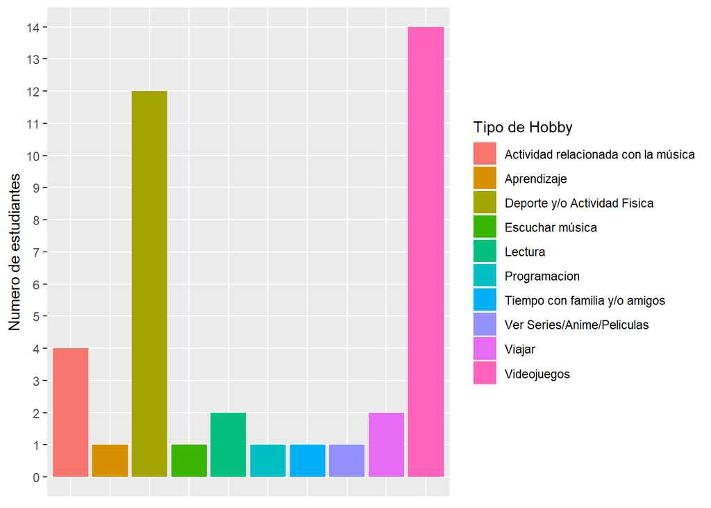

Analizando el nivel de avance podemos notar que las personas en octavo y noveno semestre son las que mas se han inscrito al curso con 9 estudiantes o mas , mientras que personas de un avance en semestres de 5,6,12,13 son de un numero reducido, asi tambien se observa una tendencia de que la personas de semestres superiores tienden a trabajar , y ya estar en el ambito laboral ,especialmente desde el noveno semestre.

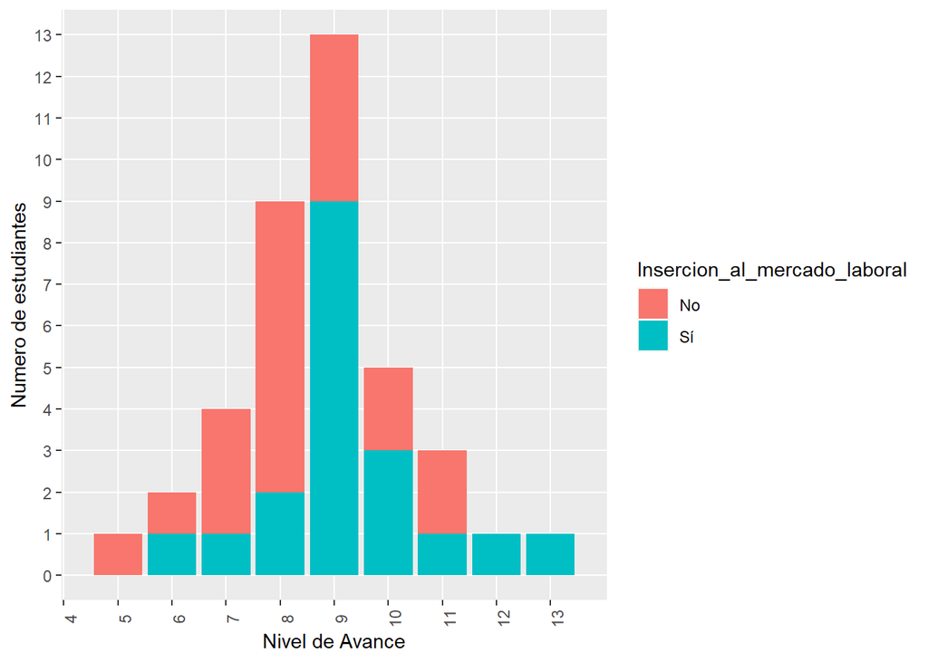

Analizando el genero de los estudiantes por carrera podemos ver que , hay una predominancia del genero masculino en casi todos los programas academicos con excepcion de Mathematical Data Science , el cual solo cuenta con un estudiante de genero femenino , Sin embargo bajo esa misma logica se rigen los programas academicos con un solo estudiantes asi que de ahi no se podria tomar como algo representativo en esas carreras , donde realmente se llama la atencion en es estadistica que los generos estan balanceados un poco , asi mismo en ingenieria de sistemas cuenta con una cantidad bastante elevada de estudiantes de genero masculino en comparacion al genero opuesto.

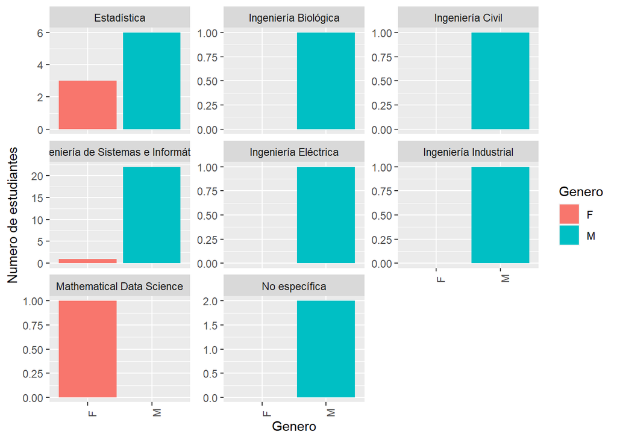